# Analiza componentelor principale Modele generalizate de rang scăzut Codificatoare automate

Procopie Gabriel (grupa 405)  
Ana-Maria Marin (grupa 405)  
03/01/2022

# Cuprins

- Analiza componentelor principale
  - Descriere generală
  - Determinarea componentelor principale
  - Etapele realizării PCA
- Modele generate de rang scăzut
  - Descriere generală
  - Etapele realizării GLRM
- Codificatoare automate
  - Descrierea generală
  - Tipuri de arhitecturi
    - Codificatoare automate incomplete
    - Codificatoare automate stivă
    - Codificatoare automate de reconstrucție
  - Etapele realizării unui codificator automat

# Analiza componentelor principale

# Analiza componentelor principale

DESCRIERE GENERALĂ

# Analiza componentelor principale

DESCRIERE GENERALĂ

Analiza componentelor principale ( Principal Component Analysis ) este o metoda de a găsi reprezentările de mici dimensiuni ale seturilor de date care rețin pe cât de mult posibil din variația originală. Ideea este că fiecare dintre cele n observații se află în spațiul p-dimensional, unde nu toate dimensiunile sunt la fel de interesante.  
În PCA căutăm un număr cât mai mic de dimensiuni care să fie cât mai interesante. Acest concept de interesant este măsurat prin cantitatea în care observațiile variază de-a lungul fiecărei dimensiuni. Fiecare dintre noile dimensiuni găsite în PCA este o combinație liniară a observațiilor inițiale în p-dimensional. Speranța este de a folosi un mic set de date ale acestor combinații ale caracteristicilor lineare în analize ulterioare, păstrând în acelați timp majoritatea informațiilor prezente în datele originale.  
Metodele de reducere a dimensiunii cum ar fi PCA, se concentrează pe reducerea spațiului de caracteristici, permițând majorității informațiilor sau variației in setul de date să fie explicate folosind puține caracteristici. În cazul PCA, aceste caracteristici vor fi necorelate.

# Analiza componentelor principale

DETERMINAREA COMPONENTELOR PRINCIPALE

Prima componentă principală a setului caracteristici $X_{1},X_{2}, ...,X_{p}$ este o combinație liniară a caracteristicilor
$$\hspace{110pt} Z_{1} = \phi_{11}X_{1} + \phi_{21}X_{2} + ... +\phi_{p1}X_{p} \hspace{110pt} (1)$$
care are varianţa cea mai mare. În acest caz, vom considera $\phi_{1}$ = $( \phi_{11} , \phi_{21},...,\phi_{p1} )$ ca fiind vectorul de încărcare pentru prima componentă principală. Luând în considerare că vectorii $\phi$ sunt normalizaţi, atunci conform definiţiei ştim că $\sum_{j=1}^{p} \phi_{j1}^{2}$ = 1

După ce prima componentă principală $Z_{1}$ a fost determinată, putem să găsim a doua componentă principală $Z_{2}$. A doua componentă principală este o combinaţie liniară a $X_{1},X_{2}, ...,X_{p}$ care are variaţia maximală din toate combinaţiile liniare care nu sunt corelate cu $Z_{1}$:
$$\hspace{110pt} Z_{2} = \phi_{12}X_{1} + \phi_{22}X_{2} + ... +\phi_{p2}X_{p} \hspace{110pt} (2)$$
unde de asemenea vom defini $\phi_{2}$ = $( \phi_{12} , \phi_{22},...,\phi_{p2} )$ ca fiind vectorul de încărcare pentru a doua componentă principală. Acest proces continuă până când toate p componente principale sunt calculate.

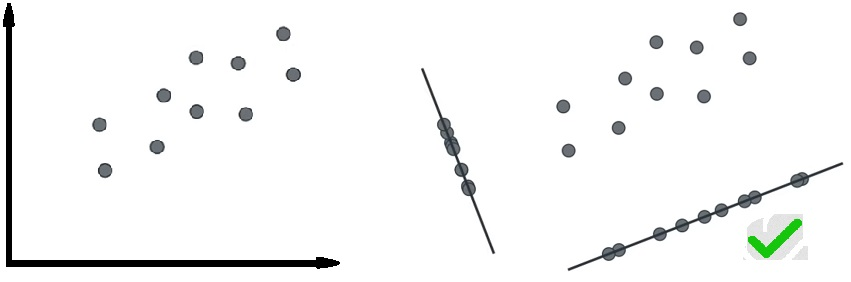

# Analiza componentelor principale

Etapele realizării PCA

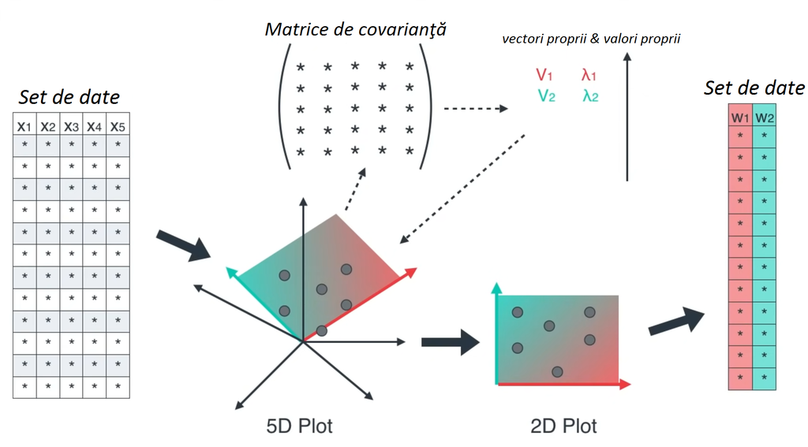

# Analiza componentelor principale

PAS 1  
1. Stabilirea setului de date.  
2. Centrarea și scalarea datelor.

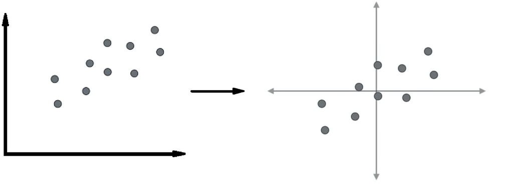

# Analiza componentelor principale

Pentru a aplica tehnicile de reducere a dimensiunii în R, datele trebuie să fie filtrate prin următorii paşi:  
1. Setul de date trebuie să fie într-un format ordonat ( [detalii](https://drive.google.com/file/d/1fFv2hfI2OGRkged6URML3h2k06CIN6kk/view?usp=sharing) ).  
2. Oricare valoarea lipsă în setul de date trebuie să fie stearsă sau introdusă.  
3. Datele trebuie să fie toate valori numerice ( de exemplu observaţie, etichetă, caracteristică categorică cu o codificare ordinală ) .  
4. Datele numerice ar trebui să fie standardizate ( de exemplu centrate şi scalate) pentru a face observaţiile comparabile.

```
##        MAMMAL top.incisor bottom.incisor top.cannine bot.cannine top.premol
## 1 RIVER OTTER           3              3           1           1          4
## 2        MOLE           3              2           1           0          3
## 3    REINDEER           0              4           1           0          3
## 4      WEASEL           3              3           1           1          3
## 5   HOUSE BAT           2              3           1           1          1
## 6     RED BAT           1              3           1           1          2
##   botpremol topmolar botmolar totals
## 1         3        1        2     18
## 2         3        3        3     18
## 3         3        3        3     17
## 4         3        1        2     17
## 5         2        3        3     16
## 6         2        3        3     16
```

Vizualizarea relației dintre date

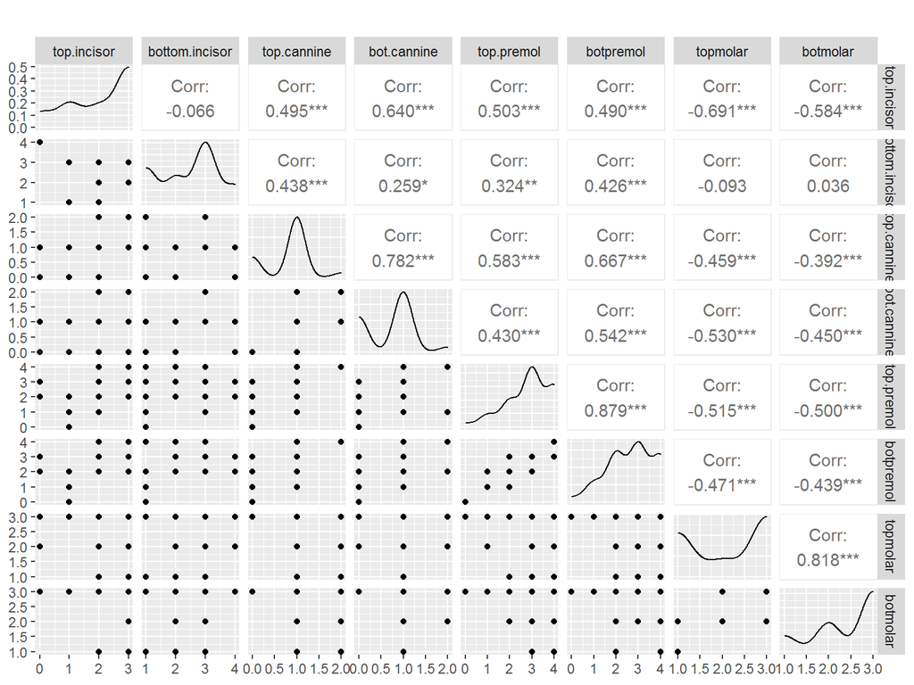

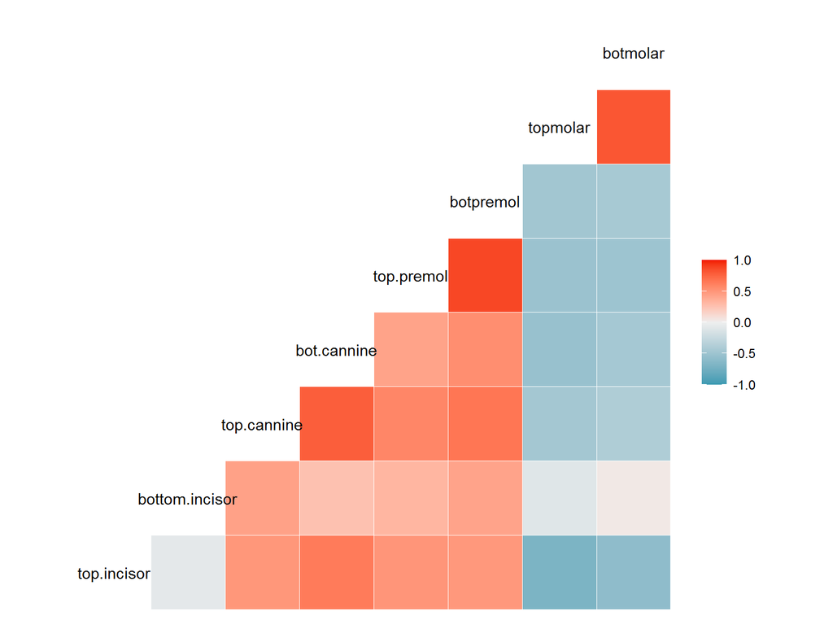

# Analiza componentelor principale

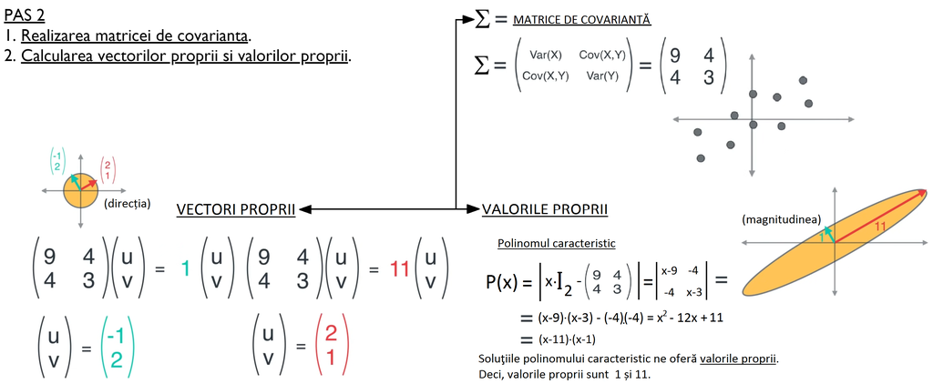

# Analiza componentelor principale

Matricea de covarianță

|  | top.incisor | bottom.incisor | top.cannine | bot.cannine | top.premol | botpremol | topmolar | botmolar |
| --- | --- | --- | --- | --- | --- | --- | --- | --- |
| top.incisor | 1.00 | -0.07 | 0.49 | 0.64 | 0.50 | 0.49 | -0.69 | -0.58 |
| bottom.incisor | -0.07 | 1.00 | 0.44 | 0.26 | 0.32 | 0.43 | -0.09 | 0.04 |
| top.cannine | 0.49 | 0.44 | 1.00 | 0.78 | 0.58 | 0.67 | -0.46 | -0.39 |
| bot.cannine | 0.64 | 0.26 | 0.78 | 1.00 | 0.43 | 0.54 | -0.53 | -0.45 |
| top.premol | 0.50 | 0.32 | 0.58 | 0.43 | 1.00 | 0.88 | -0.51 | -0.50 |
| botpremol | 0.49 | 0.43 | 0.67 | 0.54 | 0.88 | 1.00 | -0.47 | -0.44 |
| topmolar | -0.69 | -0.09 | -0.46 | -0.53 | -0.51 | -0.47 | 1.00 | 0.82 |
| botmolar | -0.58 | 0.04 | -0.39 | -0.45 | -0.50 | -0.44 | 0.82 | 1.00 |

Valorile proprii

|  | valoare proprie |
| --- | --- |
| Comp.1 | 4.48 |
| Comp.2 | 1.44 |
| Comp.3 | 0.77 |
| Comp.4 | 0.58 |
| Comp.5 | 0.32 |
| Comp.6 | 0.17 |
| Comp.7 | 0.14 |
| Comp.8 | 0.10 |

Vectori proprii

|  | 1-vector | 2-vector | 3-vector | 4-vector | 5-vector | 6-vector | 7-vector | 8-vector |
| --- | --- | --- | --- | --- | --- | --- | --- | --- |
| top.incisor | -0.36 | 0.33 | -0.19 | 0.28 | -0.68 | 0.13 | -0.39 | -0.06 |
| bottom.incisor | -0.16 | -0.67 | 0.01 | -0.58 | -0.38 | -0.07 | -0.22 | 0.06 |
| top.cannine | -0.38 | -0.26 | -0.38 | 0.07 | 0.41 | 0.67 | -0.11 | -0.10 |
| bot.cannine | -0.37 | -0.03 | -0.62 | 0.07 | 0.13 | -0.59 | 0.21 | 0.26 |
| top.premol | -0.38 | -0.17 | 0.51 | 0.32 | 0.03 | 0.07 | 0.06 | 0.67 |
| botpremol | -0.39 | -0.27 | 0.33 | 0.32 | 0.04 | -0.28 | 0.13 | -0.68 |
| topmolar | 0.37 | -0.34 | -0.10 | 0.46 | 0.18 | -0.23 | -0.66 | 0.06 |
| botmolar | 0.34 | -0.40 | -0.23 | 0.41 | -0.41 | 0.21 | 0.54 | 0.03 |

# Analiza componentelor principale

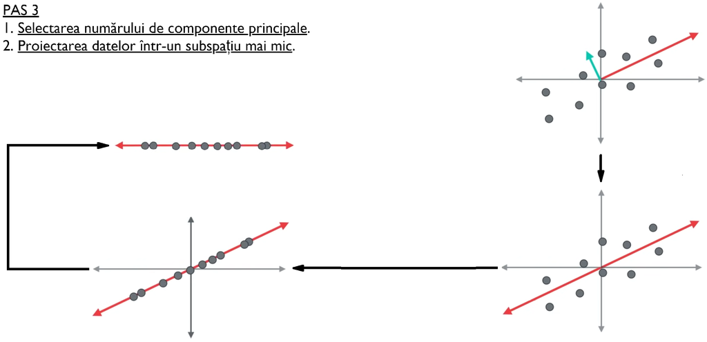

# Analiza componentelor principale

Vizualizarea componentelor principale

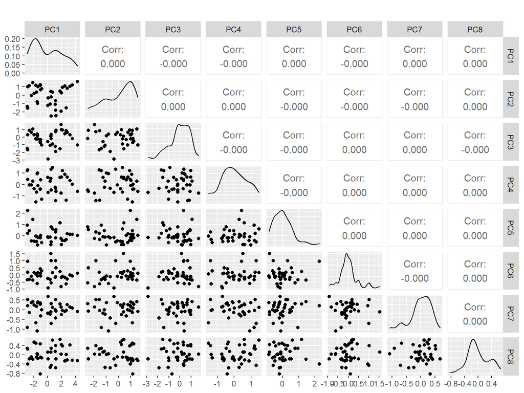

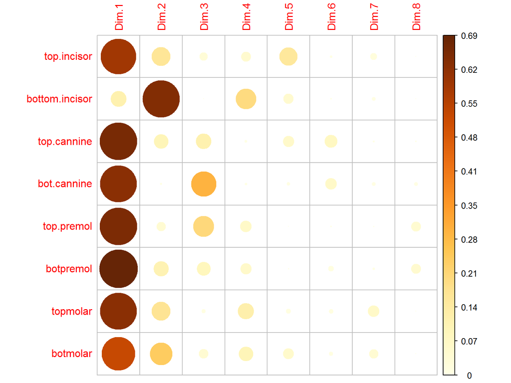

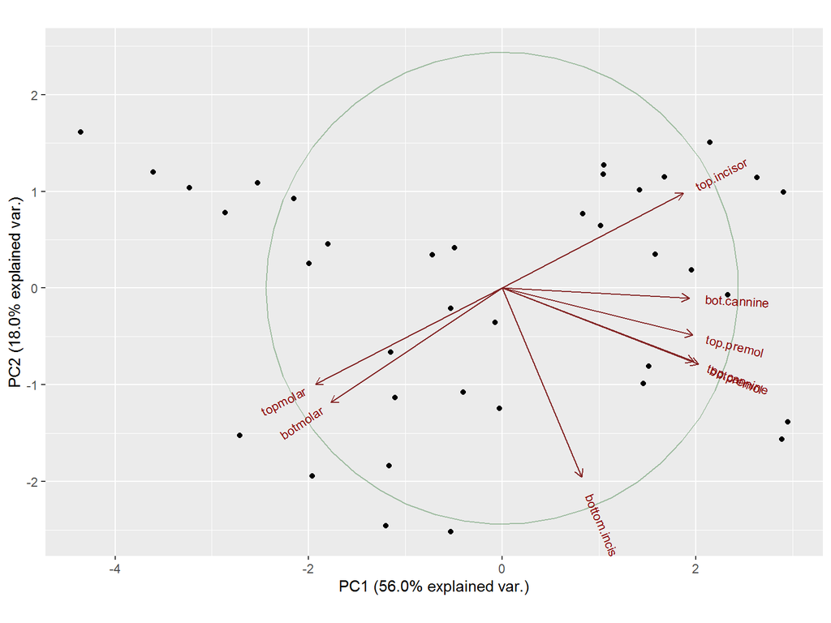

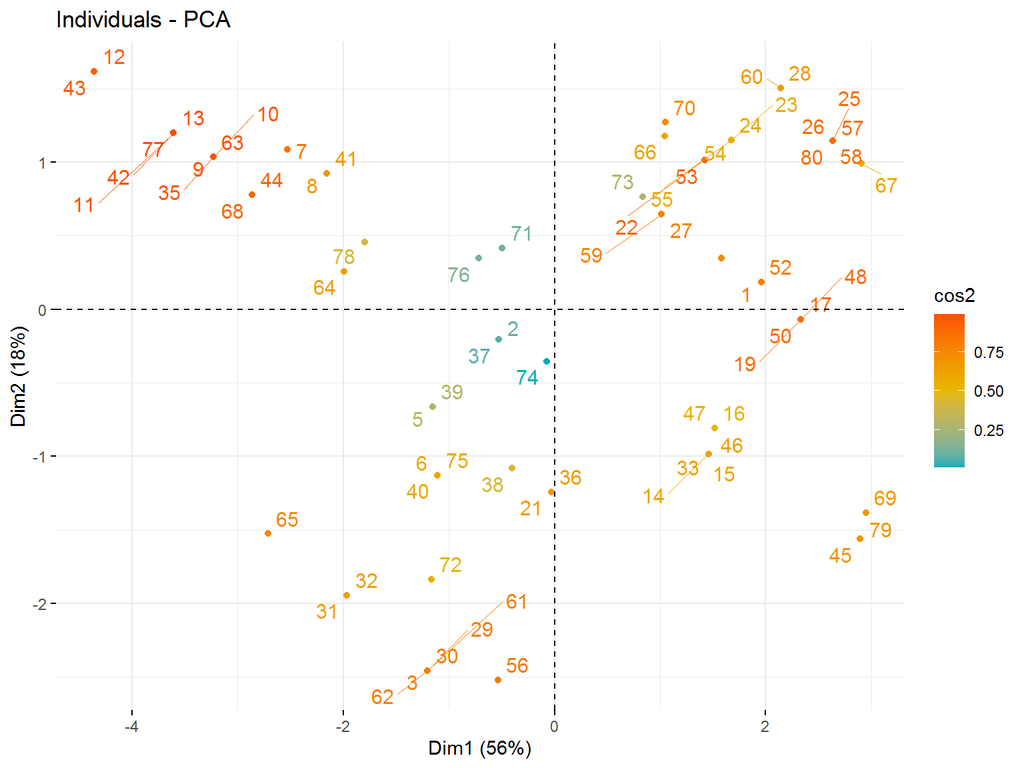

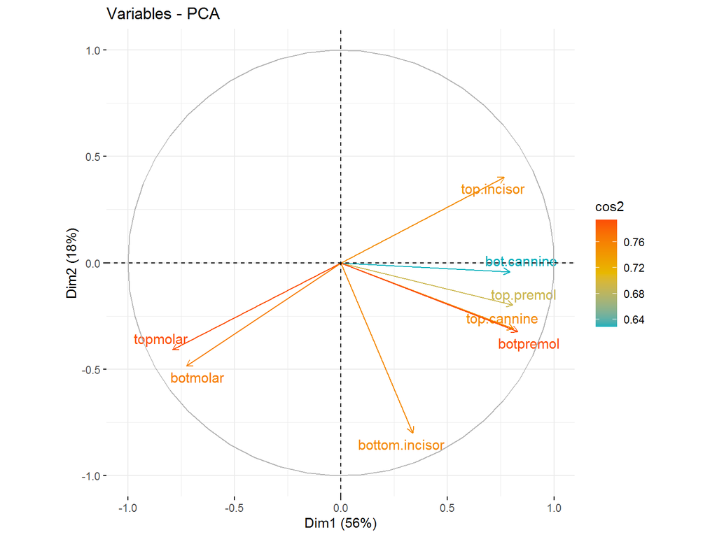

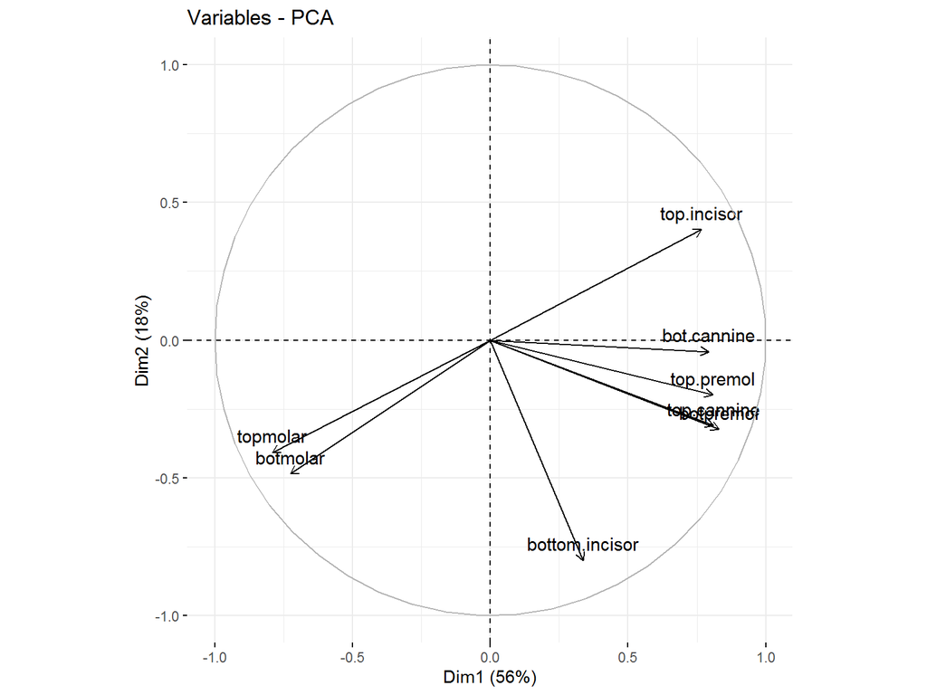

# Analiza componentelor principale

Selectarea numărului de componente principale

Selectarea componentelor principale se poate realiza prin două criterii în funcție de necesitate.  
1. Criteriul valorilor proprii.  
2. Criteriul varianţei componentelor.  
La baza acestor criterii, se află grafice scree plot. Cele mai multe grafice de acest fel arată în general asemănătoare ca formă.  
Acestea încep din partea stânga şi se îndreaptă cu rapiditate în jos aplatizându-se la un moment dat. Acest lucru se datorează faptului că prima componentă explică de obicei o mare parte din varianță. Următoarele câteva componente explică o cantitate moderată, iar ultimele componente explică doar o mică parte din varianța globală. Scree plot-ul caută “cotul” în curbă şi selectează toate componentele chiar înainte ca linia să se aplatizeze.

# Analiza componentelor principale

1. Criteriul valorilor proprii.

Valorile proprii vor varia începând cu valori mai mari ca 1 până la aproape 0. Suma valorilor proprii este egală cu numărul de variabile.

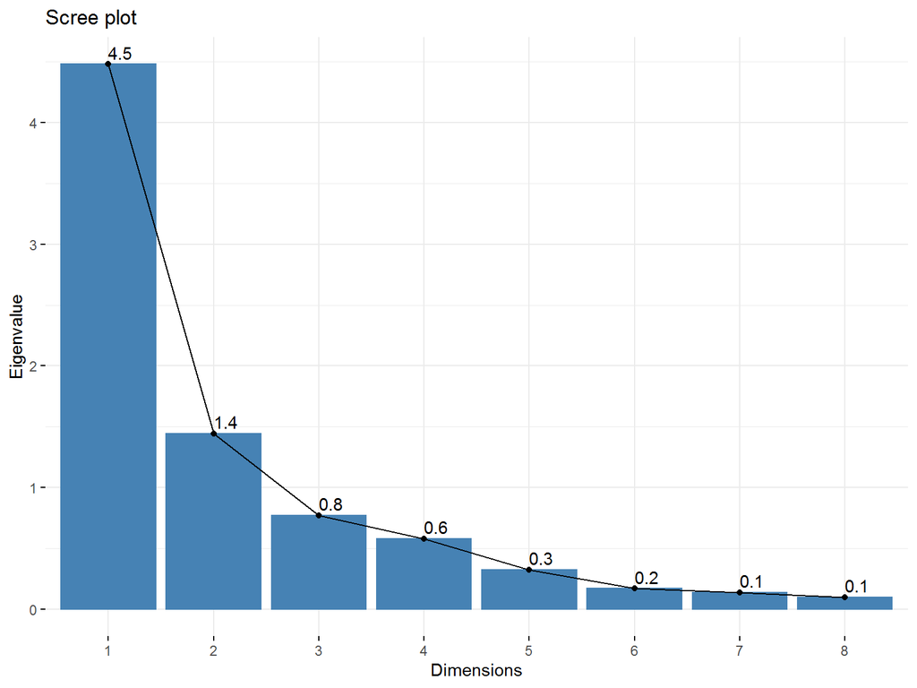

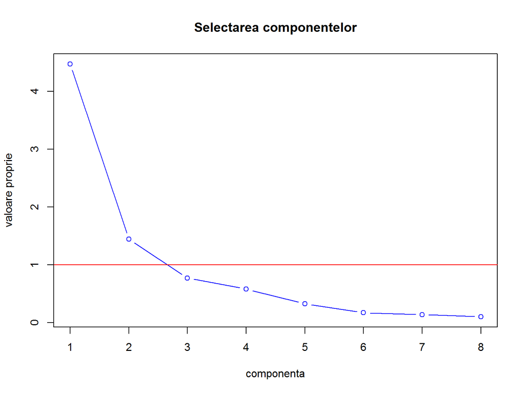

# Analiza componentelor principale

2. Criteriul varianţei componentelor.

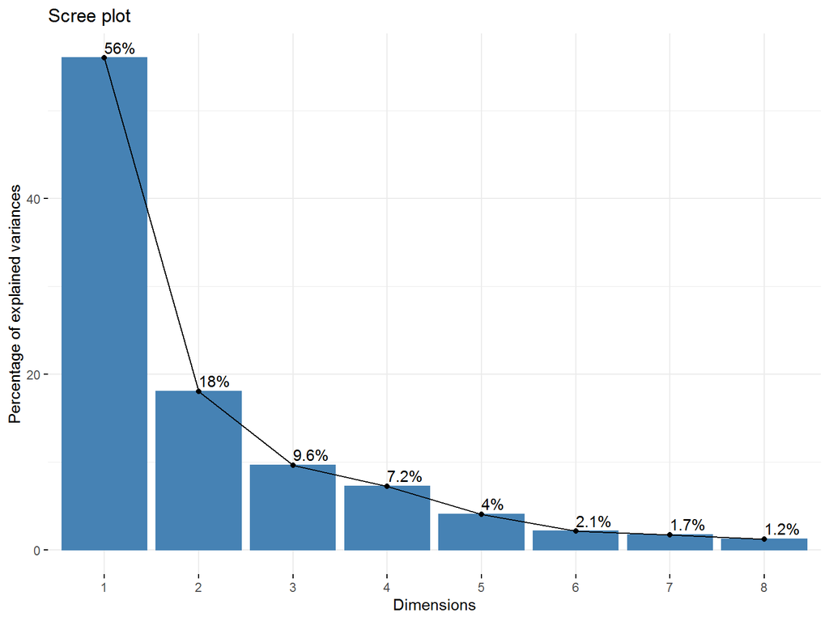

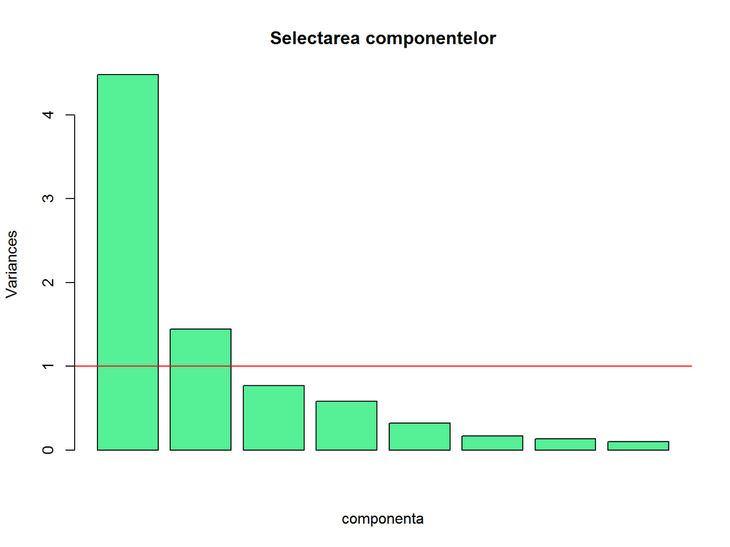

# Analiza componentelor principale

Proiectarea datelor într-un spaţiu mai mic

[figure not shown]

[figure not shown]